# LendingClub data analysis and exploration

Kim

# Lending Club:

Lending Club (LC) is a peer to peer online lending platform. It is the world’s largest marketplace connecting borrowers and investors, where consumers and small business owners lower the cost of their credit and enjoy a better experience than traditional bank lending, and investors earn attractive risk-adjusted returns.

# Goal Objective

Data exploration and analysis on the Lendingclub loan dataset. Source: https://www.lendingclub.com/info/download-data.action

## Loading dataset & library

```r
library(ggplot2)
library(plotly)
library(dplyr)
library(DescTools)
library(data.table)
library(lubridate)

dat = read.csv("LoanStats3a_securev1.csv", stringsAsFactors = FALSE, header = T, skip = 1)
```

## Data cleaning and remove NA/missing value

```r
## detect NA value in each column/variables
na_count <- sapply(dat, function(y) sum(length(which(is.na(y)))))
na_count <- as.data.frame(na_count)

##define function to remove fields that consist more than 80% missing values/NA
many_NA <- sapply(dat, function(x) {
  coverage <- 1 - sum(is.na(x)) / length(x)
  coverage < 0.8
})

dat <- dat[,many_NA==FALSE]

#remove NA rows
dat <- na.omit(dat)
```

## data manipulation and groupin

```r
library(stringr)

dat$revol_util <- str_replace_all(dat$revol_util, "[%]", "")
dat$revol_util <- as.numeric(dat$revol_util)
dat$int_rate <- str_replace_all(dat$int_rate, "[%]", "")
dat$int_rate <- as.numeric(dat$int_rate)

## convert data format(dec-2011) to R readabale date format (2011-12-01)
dat$issue_d <- dmy(paste0("01-",dat$issue_d))

## identify rent
dat$is_rent <- dat$home_ownership=="RENT"
dat$is_rent <- as.numeric(dat$is_rent)

# calculate fico average score, and group them into 8 groups
dat$ficoavg <- (dat$fico_range_low+dat$fico_range_high)/2
dat$ficogroup<-cut(dat$ficoavg,c(640,670,700,730,760,790,820,850))

# Grouping for Debt-to-income ratio
dat$dti_group<-cut(dat$dti,breaks=10)

## Grouping for annual-inc ratio
dat$annual_inc_group<-cut(dat$annual_inc,c(0,30000,40000,50000,60000,70000,80000,90000,max(dat$annual_inc)))
```

## Exploratory Data Analysis

### Loan amount issued across year

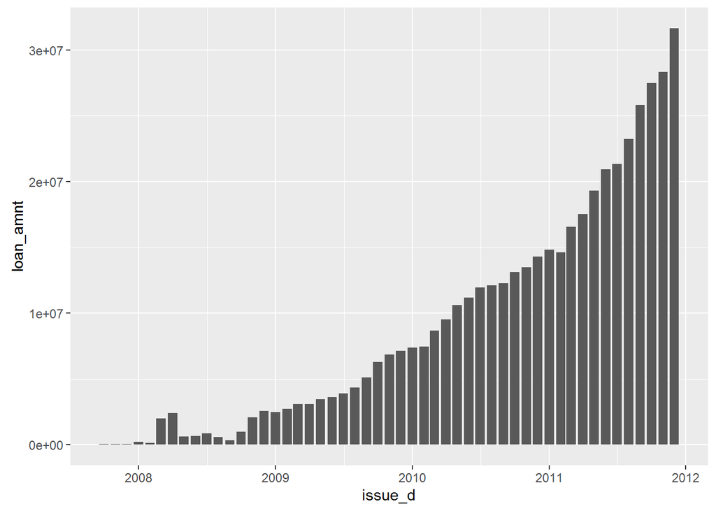

```r
loan_amnt_by_month <- aggregate(loan_amnt ~ issue_d, data = dat, sum)
ggplot(loan_amnt_by_month, aes(issue_d, loan_amnt)) + geom_bar(stat = "identity")
```

### Loan amount issued across LC loan grade

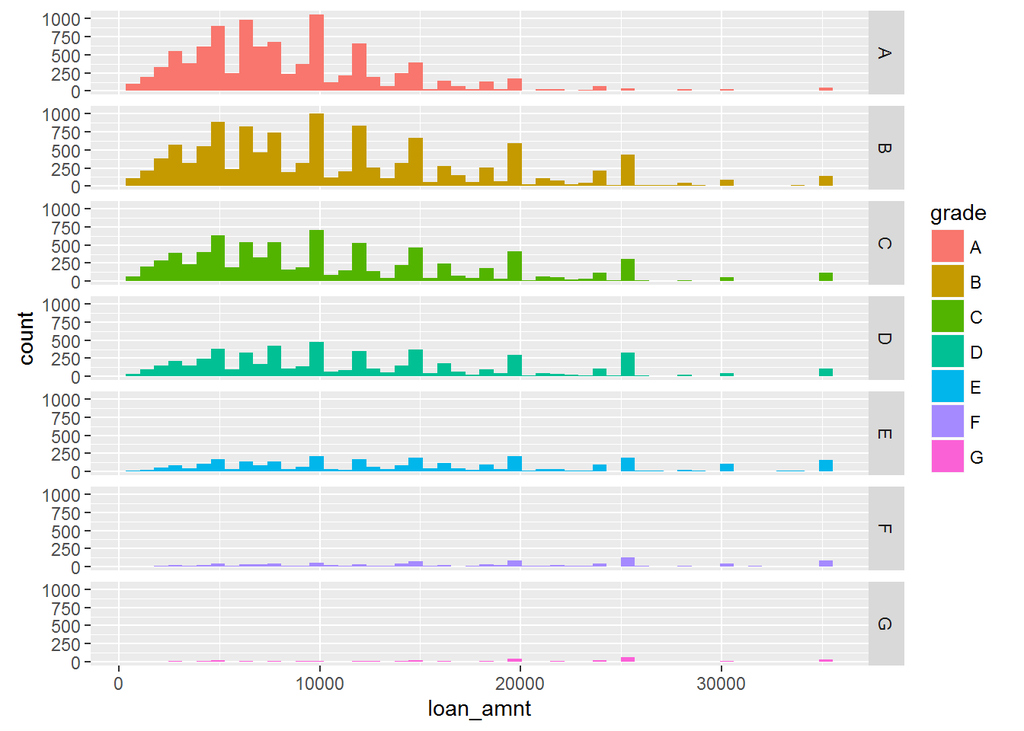

```r
ggplot(dat, aes(loan_amnt, fill = grade)) + geom_histogram(bins = 50) + facet_grid(grade ~ .)
```

Loan grade of A,B,C has a higher rate of loan amount issued compare to loan grade of D,E,F.

### Purpose of loan

```r
df <- as.data.frame(table(dat$purpose))
plot_ly(df, labels = Var1, values = Freq, type = "pie") %>%layout(title = "Purpose of loan")
```

[interactive chart not shown]

### Loan status

```r
df2 <- as.data.frame(table(dat$loan_status))
plot_ly(df2, labels = Var1, values = Freq, type = "pie") %>% layout(title = "loan status")
```

[interactive chart not shown]

### Average FICO score

```r
df3 <- as.data.frame(table(dat$ficogroup))
plot_ly(df3, labels = Var1, values = Freq, type = "pie") %>% layout(title = "Average FICO score")
```

[interactive chart not shown]

### Average FICO score versus LC subgrade

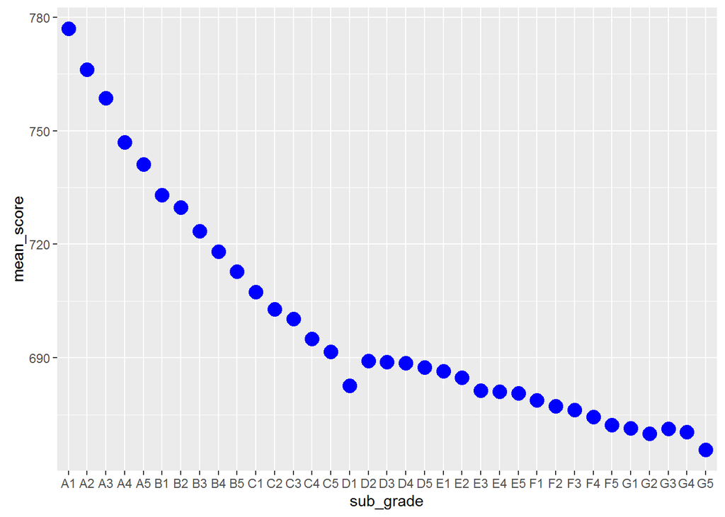

```r
df4 <- dat %>%
      group_by(sub_grade) %>%
      summarise(mean_score = mean(ficoavg))
df4 <- as.data.frame(df4)
ggplot(df4,aes(sub_grade,mean_score))+geom_point(colour="blue", size = 4.5)
```

There is a correlation between Average FICO score and the LendingClub subgrade

### Interest rate across different LC loan grade

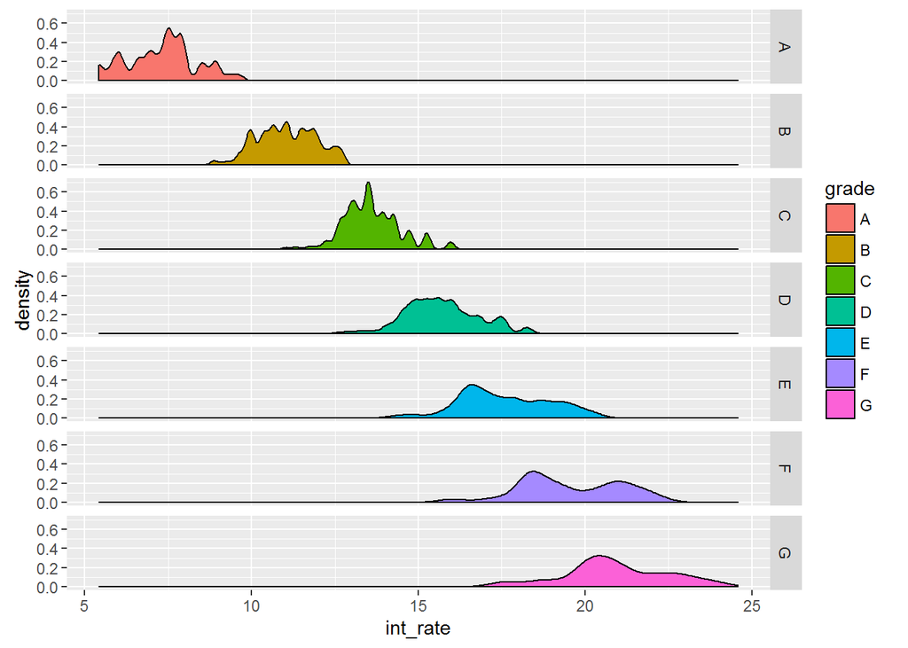

```r
ggplot(dat, aes(int_rate, fill = grade)) + geom_density() + facet_grid(grade ~ .)
```

Loan grade were categorized based on risk:  
Grade A = least risky, lowest interest rate, wherease Grade G = most risky, highest interest rate

# Let’s define default loan category:

```r
# from loan_status, assign some indicator to default
default_indicator <- c("Charged Off ",
                      "Default",
                       "Does not meet the credit policy. Status:Charged Off",
                       "Default Receiver")

dat$is_default <- ifelse(dat$loan_status %in% default_indicator, 1,
                     ifelse(dat$loan_status=="", NA, 0)
)
```

## Default rate across different LC subgrade

```r
df5 <- dat %>%
    group_by(sub_grade) %>%
      # mutate(default_count = sum(is_default=="1")) %>%
    summarise(default_count = sum(is_default), number_of_loans=n(),default_rate= default_count/n())

df5 <- as.data.frame(df5)
g<- ggplot(df5,aes(number_of_loans,default_rate))+geom_point(aes(colour=sub_grade,size=default_rate))
ggplotly(g)
```

[interactive chart not shown]

(Default rate is in ratio, 0.15 = 15%) There is a strong correlation between LC loan grade with default rate The default rate goes higher when the loan grade drop

## Default rate across different employment length

```
## Source: local data frame [12 x 4]
##
##    emp_length number_of_loans default_count default_rate
##         (chr)           (int)         (dbl)        (dbl)
## 1    < 1 year            4715            58   0.01230117
## 2      1 year            3380            54   0.01597633
## 3   10+ years            9169           125   0.01363289
## 4     2 years            4579            61   0.01332169
## 5     3 years            4246            53   0.01248234
## 6     4 years            3559            41   0.01152009
## 7     5 years            3392            36   0.01061321
## 8     6 years            2313            34   0.01469952
## 9     7 years            1833            22   0.01200218
## 10    8 years            1555            30   0.01929260
## 11    9 years            1311            17   0.01296720
## 12        n/a            1112            16   0.01438849
```

## Default rate across delinquencies over the pass 2 years

```
## Source: local data frame [11 x 4]
##
##    delinq_2yrs number_of_loans default_count default_rate
##          (int)           (int)         (dbl)        (dbl)
## 1            0           36638           462   0.01260986
## 2            1            3460            63   0.01820809
## 3            2             724            16   0.02209945
## 4            3             229             4   0.01746725
## 5            4              65             1   0.01538462
## 6            5              26             0   0.00000000
## 7            6              12             1   0.08333333
## 8            7               5             0   0.00000000
## 9            8               2             0   0.00000000
## 10           9               1             0   0.00000000
## 11          11               2             0   0.00000000
```

## Default rate across Debt-to-income ratio

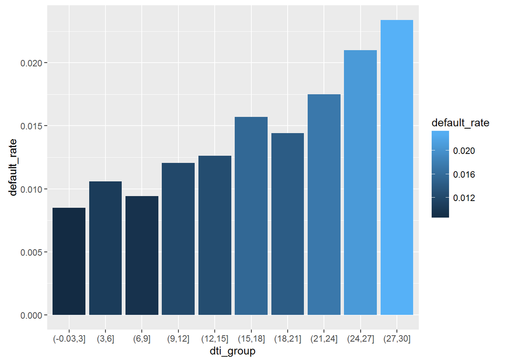

There is a correlation between default rate and debt-to-income ratio

## Default rate across Annual income

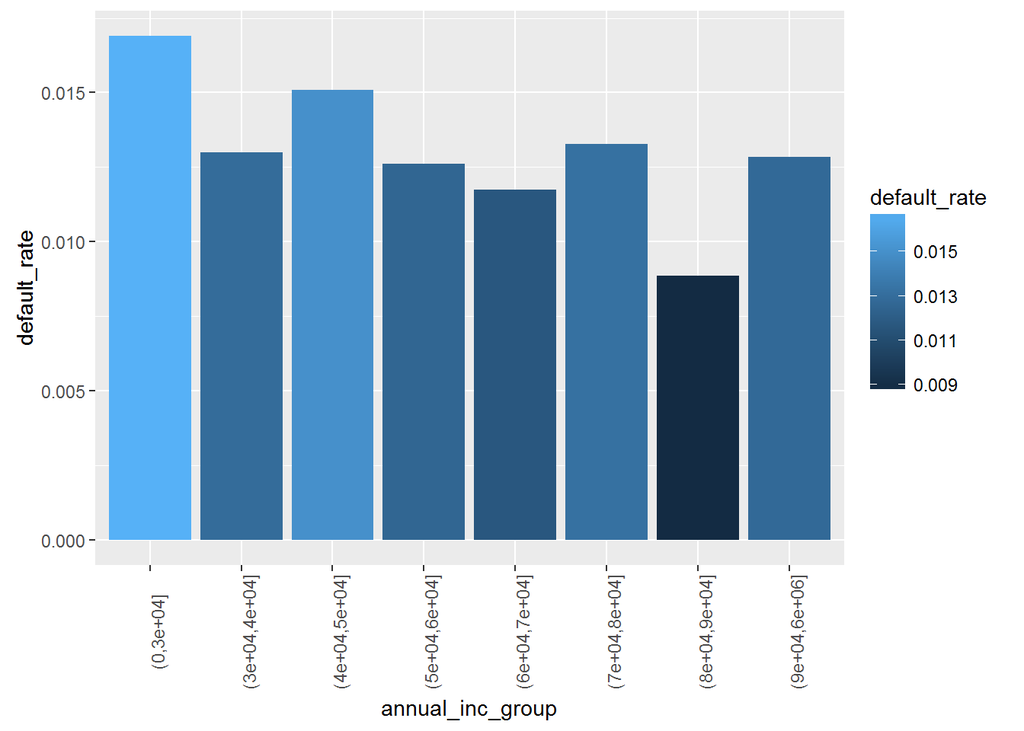

There is minimium correlation between default rate versus annual income

## Default rate across Inquiries in the past 6 months

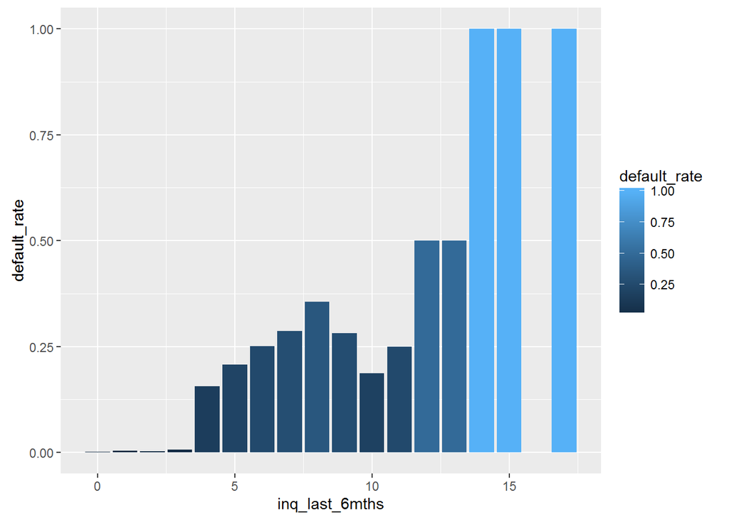

There is a strong correlation between Inquiries in the past 6 months versus default rate.

# Conclusion

Lending Club’s data is a great source of information on personal credit. From the analysis above, we identify the potential feature used to predict default rate and bad loan. This include LC loan grade, inquiries in the past 6 months, Debt-to-income ratio.

Further exploration and work:  
1) Building a credit model and see if we can predict reliably defaults  
2) Building an interactive dashboard or predictive API for end-user application  
3) Using elasticsearch & kibana dashboard to gain dynamic searching and visualization